# metode_vsm

**PENCARIAN DAN PENAMBANGAN WEB - TUGAS 2 : Membuat VSM dan Menghitung TF-IDF berdasarkan hasil crawling berita**

Nama : Isnita Widyur Rahmah NIM : 220411100048 Kelas : IF 7A

Link Project : https://github.com/taawdyy/ppw

**Vector Space Model dalam Pengolahan Teks**

Vector Space Model (VSM) adalah pendekatan yang merepresentasikan setiap kata sebagai dimensi dalam ruang vektor, di mana dokumen dipandang sebagai vektor dengan magnitude (jarak) dan direction (arah). Relevansi dokumen terhadap kueri ditentukan berdasarkan kesamaan antara vektor dokumen dan vektor kueri.

VSM memungkinkan pencocokan parsial dengan menetapkan bobot non-biner untuk istilah dalam kueri dan dokumen. Bobot ini digunakan untuk menghitung tingkat kesamaan antara dokumen dan permintaan pengguna. Dokumen yang relevan disortir berdasarkan kemiripan, sehingga menghasilkan himpunan dokumen yang lebih akurat. Dalam model ini, baik dokumen ( d_j ) maupun kueri ( q ) direpresentasikan sebagai vektor t-dimensi.

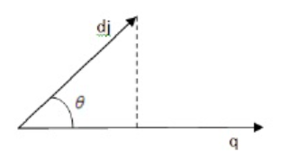

Dalam VSM, koleksi dokumen direpresentasikan sebagai sebuah matrik term-document (atau matrik term frequency). Setiap sel dalam matrik bersesuaian dengan bobot yang diberikan dari suatu term dalam dokumen yang ditentukan. Nilai nol berarti bahwa term tersebut tidak ada dalam dokumen.

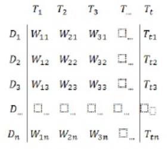

**TF-IDF (Term Frequency-Inverse Document Frequency)**

TF-IDF (Term Frequency-Inverse Document Frequency) adalah metode yang digunakan dalam pengolahan teks dan analisis informasi untuk menilai seberapa penting sebuah kata dalam suatu dokumen relatif terhadap koleksi dokumen (corpus). Metode ini sering digunakan dalam pencarian informasi dan penambangan teks.

TF mengukur seberapa sering suatu kata muncul dalam dokumen. Semakin sering kata muncul, semakin tinggi nilai TF-nya.

IDF mengukur seberapa umum atau jarang sebuah kata di seluruh dokumen. Kata yang muncul di banyak dokumen akan memiliki nilai IDF yang rendah, sedangkan kata yang jarang muncul akan memiliki nilai IDF yang tinggi

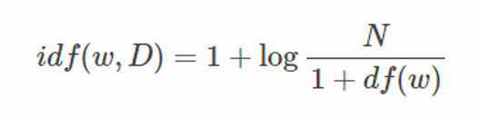

Setelah mendapatkan nilai TF dan IDF, nilai TF-IDF dapat dihitung dengan rumus berikut:

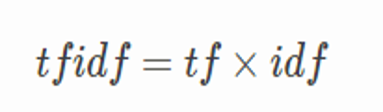

Import Library

```python
!pip install Sastrawi
!pip install pandas
```

```python
import pandas as pd
import re

from tqdm import tqdm

import nltk
nltk.download('stopwords')
nltk.download('wordnet')
nltk.download('punkt')
from nltk.corpus import stopwords
from Sastrawi.Stemmer.StemmerFactory import StemmerFactory

from sklearn.feature_extraction.text import CountVectorizer
from sklearn.feature_extraction.text import TfidfVectorizer
```

Load Data

```python
# Ganti 'crawling_berita.csv' dengan nama file CSV yang ingin diimpor
file_path = 'crawl_berita.csv'

# Mengimpor data dari file CSV
df = pd.read_csv(file_path)

# Menampilkan DataFrame yang diimpor
df  # Menampilkan seluruh DataFrame
```

|  | Judul | Isi | Tanggal | Kategori |
| --- | --- | --- | --- | --- |
| 0 | Pertemuan Sri Mulyani-Prabowo Tak Banyak Bahas... | Wakil Menteri Keuangan II Thomas Djiwandono me... | Rabu, 11 Sep 2024 18:10 WIB | Ekonomi |
| 1 | Pebisnis Minta Jokowi Cabut Larangan Jual Roko... | Gabungan pengusaha rokok dan petani tembakau m... | Rabu, 11 Sep 2024 17:31 WIB | Ekonomi |
| 2 | IHSG Melemah Tipis ke 7.760 Sore Ini | Indeks Harga Saham Gabungan (IHSG) ditutup di ... | Rabu, 11 Sep 2024 16:37 WIB | Ekonomi |
| 3 | Rupiah Menguat Rp15.402 per Dolar AS Usai Deba... | Nilai tukar rupiah berada di level Rp15.402 pe... | Rabu, 11 Sep 2024 16:24 WIB | Ekonomi |
| 4 | Sri Mulyani Usai Nonton Timnas-Australia: Teri... | Menteri Keuangan Sri MulyaniÂ berkomentar soal... | Rabu, 11 Sep 2024 15:47 WIB | Ekonomi |
| ... | ... | ... | ... | ... |
| 95 | Hasil Liga 1: PSM vs Persib Sama Kuat | PSM Makassar harus puas berbagi satu angka usa... | Rabu, 11 Sep 2024 17:25 WIB | Olahraga |
| 96 | Jokowi Beri Bonus Rp36,25 Miliar ke Peraih Med... | Presiden Joko Widodo (Jokowi) menyerahkan bonu... | Rabu, 11 Sep 2024 17:13 WIB | Olahraga |
| 97 | Megawati Ungkap Target di Liga Korea: Jadi Pem... | Megawati Hangestri Pertiwi mengungkapkan targe... | Rabu, 11 Sep 2024 16:49 WIB | Olahraga |
| 98 | Media Vietnam: Indonesia Buat Kejutan Besar La... | Media Vietnam memuji performa Timnas Indonesia... | Rabu, 11 Sep 2024 16:24 WIB | Olahraga |
| 99 | Respons PSSI soal 'Penonton Siluman' di Indone... | Anggota Komite Eksekutif (Exco) PSSI Arya Sinu... | Rabu, 11 Sep 2024 16:02 WIB | Olahraga |

100 rows × 4 columns

Mengonversi Semua Huruf Besar Menjadi Huruf Kecil

```python
def clean_lower(text):
    #  Memeriksa tipe data string
    if isinstance(text, str):
        return text.lower()
    return text

df['lower case'] = df['Isi'].apply(clean_lower)

# Membuat DataFrame Baru
casefolding = pd.DataFrame(df['lower case'])
casefolding
```

|  | lower case |
| --- | --- |
| 0 | wakil menteri keuangan ii thomas djiwandono me... |
| 1 | gabungan pengusaha rokok dan petani tembakau m... |
| 2 | indeks harga saham gabungan (ihsg) ditutup di ... |
| 3 | nilai tukar rupiah berada di level rp15.402 pe... |
| 4 | menteri keuangan sri mulyaniâ berkomentar soal... |
| ... | ... |
| 95 | psm makassar harus puas berbagi satu angka usa... |
| 96 | presiden joko widodo (jokowi) menyerahkan bonu... |
| 97 | megawati hangestri pertiwi mengungkapkan targe... |
| 98 | media vietnam memuji performa timnas indonesia... |
| 99 | anggota komite eksekutif (exco) pssi arya sinu... |

100 rows × 1 columns

Menghapus Simbol dan Angka dari Teks

```python
def clean_punct(text):
    #  Memeriksa tipe data string
    if isinstance(text, str):
        # Mencocokkan angka, tanda baca, dan karakter khusus
        clean_patterns = re.compile(r'[0-9]|[/(){}\[\]\|@,;_]|[^a-z ]')
        # Mengganti karakter yang cocok dengan spasi
        text = clean_patterns.sub(' ', text)
        # Menghapus spasi berlebih dan memangkas spasi di awal dan akhir
        text = re.sub(r'\s+', ' ', text).strip()
        return text
    return text

df['tanda baca'] = df['lower case'].apply(clean_punct)

df['tanda baca']
```

|  | tanda baca |
| --- | --- |
| 0 | wakil menteri keuangan ii thomas djiwandono me... |
| 1 | gabungan pengusaha rokok dan petani tembakau m... |
| 2 | indeks harga saham gabungan ihsg ditutup di le... |
| 3 | nilai tukar rupiah berada di level rp per dola... |
| 4 | menteri keuangan sri mulyani berkomentar soal ... |
| ... | ... |
| 95 | psm makassar harus puas berbagi satu angka usa... |
| 96 | presiden joko widodo jokowi menyerahkan bonus ... |
| 97 | megawati hangestri pertiwi mengungkapkan targe... |
| 98 | media vietnam memuji performa timnas indonesia... |
| 99 | anggota komite eksekutif exco pssi arya sinuli... |

100 rows × 1 columns

**dtype:** object

Menghapus Spasi Awal dan Akhir dari Sebuah String

```python
def _normalize_whitespace(text):
    # Memeriksa apakah input adalah string
    if isinstance(text, str):
        # Mengganti beberapa spasi berturut-turut dengan satu spasi
        corrected = re.sub(r'\s+', ' ', text)
        return corrected.strip()
    return text

df['spasi'] = df['tanda baca'].apply(_normalize_whitespace)

df['spasi']
```

|  | spasi |
| --- | --- |
| 0 | wakil menteri keuangan ii thomas djiwandono me... |
| 1 | gabungan pengusaha rokok dan petani tembakau m... |
| 2 | indeks harga saham gabungan ihsg ditutup di le... |
| 3 | nilai tukar rupiah berada di level rp per dola... |
| 4 | menteri keuangan sri mulyani berkomentar soal ... |
| ... | ... |
| 95 | psm makassar harus puas berbagi satu angka usa... |
| 96 | presiden joko widodo jokowi menyerahkan bonus ... |
| 97 | megawati hangestri pertiwi mengungkapkan targe... |
| 98 | media vietnam memuji performa timnas indonesia... |
| 99 | anggota komite eksekutif exco pssi arya sinuli... |

100 rows × 1 columns

**dtype:** object

Mengurangi Jumlah Kata dalam Sebuah Dokumen

```python
def clean_stopwords(text):
    # Memeriksa apakah input adalah string
    if isinstance(text, str):
        # Mengambil daftar stopwords dalam bahasa Indonesia
        stopword = set(stopwords.words('indonesian'))
        # Menghapus stopwords dari teks
        text = ' '.join(word for word in text.split() if word not in stopword)
        return text.strip()
    return text

df['stopwords'] = df['spasi'].apply(clean_stopwords)

df['stopwords']
```

|  | stopwords |
| --- | --- |
| 0 | wakil menteri keuangan ii thomas djiwandono pe... |
| 1 | gabungan pengusaha rokok petani tembakau presi... |
| 2 | indeks harga saham gabungan ihsg ditutup level... |
| 3 | nilai tukar rupiah level rp dolar as rabu sore... |
| 4 | menteri keuangan sri mulyani berkomentar perfo... |
| ... | ... |
| 95 | psm makassar puas berbagi angka bermain imbang... |
| 96 | presiden joko widodo jokowi menyerahkan bonus ... |
| 97 | megawati hangestri pertiwi target musim liga v... |
| 98 | media vietnam memuji performa timnas indonesia... |
| 99 | anggota komite eksekutif exco pssi arya sinuli... |

100 rows × 1 columns

**dtype:** object

Mereduksi Kata Menjadi Bentuk Dasar

```python
def sastrawistemmer(text):
    factory = StemmerFactory()
    st = factory.create_stemmer()
    # Melakukan stemming pada setiap kata dalam teks
    text = ' '.join(st.stem(word) for word in tqdm(text.split()) if word in text)
    return text

df['stemming'] = df['stopwords'].apply(sastrawistemmer)

df['stemming']
```

|  | stemming |
| --- | --- |
| 0 | wakil menteri uang ii thomas djiwandono temu m... |
| 1 | gabung usaha rokok tani tembakau presiden joko... |
| 2 | indeks harga saham gabung ihsg tutup level rab... |
| 3 | nilai tukar rupiah level rp dolar as rabu sore... |
| 4 | menteri uang sri mulyani komentar performa tim... |
| ... | ... |
| 95 | psm makassar puas bagi angka main imbang lawan... |
| 96 | presiden joko widodo jokowi serah bonus atlet ... |
| 97 | megawati hangestri pertiwi target musim liga v... |
| 98 | media vietnam puji performa timnas indonesia h... |
| 99 | anggota komite eksekutif exco pssi arya sinuli... |

100 rows × 1 columns

**dtype:** object

Pembuatan Vector Space Model (VSM)

```python
count_vectorizer = CountVectorizer()

if 'stemming' in df.columns:
    # Mengambil nilai dari kolom 'stemming', menghapus NaN, dan mengubahnya menjadi list
    corpus = df['stemming'].dropna().tolist()
else:
    raise KeyError("Kolom 'stemming' tidak ada di DataFrame")

# Menghitung frekuensi kata dan mengubahnya menjadi matriks
x_count = count_vectorizer.fit_transform(corpus)

# Mengambil nama fitur (kata-kata unik) dari CountVectorizer
feature_names = count_vectorizer.get_feature_names_out()

# Mengonversi matriks sparse ke dalam DataFrame pandas
x_count_df = pd.DataFrame(x_count.toarray(), columns=feature_names)

x_count_df
```

|  | abroad | absolut | acara | achmad | acu | adab | adam | adaptif | adb | adi | ... | yoppy | yuan | yudha | yuran | yusuf | zayana | zona | zonasi | zulhas | zulkifli |
| --- | --- | --- | --- | --- | --- | --- | --- | --- | --- | --- | --- | --- | --- | --- | --- | --- | --- | --- | --- | --- | --- |
| 0 | 0 | 0 | 0 | 0 | 0 | 0 | 0 | 0 | 0 | 0 | ... | 0 | 0 | 0 | 0 | 0 | 0 | 0 | 0 | 0 | 0 |
| 1 | 0 | 0 | 0 | 0 | 0 | 0 | 0 | 0 | 0 | 0 | ... | 0 | 0 | 0 | 0 | 0 | 0 | 0 | 1 | 0 | 0 |
| 2 | 0 | 0 | 0 | 0 | 0 | 0 | 0 | 0 | 0 | 0 | ... | 0 | 0 | 0 | 0 | 0 | 0 | 1 | 0 | 0 | 0 |
| 3 | 0 | 0 | 0 | 0 | 0 | 0 | 0 | 0 | 0 | 0 | ... | 0 | 1 | 0 | 0 | 0 | 0 | 2 | 0 | 0 | 0 |
| 4 | 0 | 1 | 0 | 0 | 0 | 0 | 1 | 0 | 0 | 0 | ... | 0 | 0 | 0 | 0 | 0 | 0 | 0 | 0 | 0 | 0 |
| ... | ... | ... | ... | ... | ... | ... | ... | ... | ... | ... | ... | ... | ... | ... | ... | ... | ... | ... | ... | ... | ... |
| 95 | 0 | 0 | 0 | 0 | 0 | 0 | 0 | 0 | 0 | 0 | ... | 0 | 0 | 0 | 1 | 0 | 0 | 0 | 0 | 0 | 0 |
| 96 | 0 | 0 | 0 | 0 | 0 | 0 | 0 | 0 | 0 | 0 | ... | 0 | 0 | 1 | 0 | 0 | 2 | 0 | 0 | 0 | 0 |
| 97 | 0 | 0 | 0 | 0 | 0 | 0 | 0 | 0 | 0 | 0 | ... | 0 | 0 | 0 | 0 | 0 | 0 | 0 | 0 | 0 | 0 |
| 98 | 0 | 0 | 0 | 0 | 0 | 0 | 0 | 0 | 0 | 0 | ... | 0 | 0 | 0 | 0 | 0 | 0 | 0 | 0 | 0 | 0 |
| 99 | 0 | 0 | 0 | 0 | 0 | 0 | 0 | 0 | 0 | 0 | ... | 0 | 0 | 0 | 0 | 0 | 0 | 0 | 0 | 0 | 0 |

100 rows × 1882 columns

Menghitung Term Frequency dan Invers Document Frequency (TFIDF)

```python
# Inisialisasi TfidfVectorizer
tfidf_vectorizer = TfidfVectorizer()

# Ambil teks dari kolom 'stemming' dan ubah ke list
corpus = df['stemming'].tolist()

# Ubah teks menjadi matriks TF-IDF
x_tfidf = tfidf_vectorizer.fit_transform(corpus)

# Mendapatkan daftar kata unik (fitur)
feature_names = tfidf_vectorizer.get_feature_names_out()

# Mengonversi matriks sparse ke DataFrame dan beri nama kolom sesuai dengan kata unik
tfidf_df = pd.DataFrame(x_tfidf.toarray(), columns=feature_names)

# Ambil kolom "Kategori" dari df
cat_df = df["Kategori"]

# Menambahkan kolom "Kategori" ke tfidf_df langsung dengan assign
tfidf_df['Kategori'] = cat_df.values

# Mengatur ulang kolom agar "Kategori" berada di awal
tfidf_df = tfidf_df[['Kategori'] + [col for col in tfidf_df.columns if col != 'Kategori']]

# Menampilkan DataFrame
tfidf_df
```

|  | Kategori | abroad | absolut | acara | achmad | acu | adab | adam | adaptif | adb | ... | yoppy | yuan | yudha | yuran | yusuf | zayana | zona | zonasi | zulhas | zulkifli |
| --- | --- | --- | --- | --- | --- | --- | --- | --- | --- | --- | --- | --- | --- | --- | --- | --- | --- | --- | --- | --- | --- |
| 0 | Ekonomi | 0.0 | 0.000000 | 0.0 | 0.0 | 0.0 | 0.0 | 0.000000 | 0.0 | 0.0 | ... | 0.0 | 0.000000 | 0.000000 | 0.000000 | 0.0 | 0.000000 | 0.000000 | 0.000000 | 0.0 | 0.0 |
| 1 | Ekonomi | 0.0 | 0.000000 | 0.0 | 0.0 | 0.0 | 0.0 | 0.000000 | 0.0 | 0.0 | ... | 0.0 | 0.000000 | 0.000000 | 0.000000 | 0.0 | 0.000000 | 0.000000 | 0.055924 | 0.0 | 0.0 |
| 2 | Ekonomi | 0.0 | 0.000000 | 0.0 | 0.0 | 0.0 | 0.0 | 0.000000 | 0.0 | 0.0 | ... | 0.0 | 0.000000 | 0.000000 | 0.000000 | 0.0 | 0.000000 | 0.044704 | 0.000000 | 0.0 | 0.0 |
| 3 | Ekonomi | 0.0 | 0.000000 | 0.0 | 0.0 | 0.0 | 0.0 | 0.000000 | 0.0 | 0.0 | ... | 0.0 | 0.052317 | 0.000000 | 0.000000 | 0.0 | 0.000000 | 0.084570 | 0.000000 | 0.0 | 0.0 |
| 4 | Ekonomi | 0.0 | 0.054469 | 0.0 | 0.0 | 0.0 | 0.0 | 0.054469 | 0.0 | 0.0 | ... | 0.0 | 0.000000 | 0.000000 | 0.000000 | 0.0 | 0.000000 | 0.000000 | 0.000000 | 0.0 | 0.0 |
| ... | ... | ... | ... | ... | ... | ... | ... | ... | ... | ... | ... | ... | ... | ... | ... | ... | ... | ... | ... | ... | ... |
| 95 | Olahraga | 0.0 | 0.000000 | 0.0 | 0.0 | 0.0 | 0.0 | 0.000000 | 0.0 | 0.0 | ... | 0.0 | 0.000000 | 0.000000 | 0.062649 | 0.0 | 0.000000 | 0.000000 | 0.000000 | 0.0 | 0.0 |
| 96 | Olahraga | 0.0 | 0.000000 | 0.0 | 0.0 | 0.0 | 0.0 | 0.000000 | 0.0 | 0.0 | ... | 0.0 | 0.000000 | 0.040965 | 0.000000 | 0.0 | 0.081929 | 0.000000 | 0.000000 | 0.0 | 0.0 |
| 97 | Olahraga | 0.0 | 0.000000 | 0.0 | 0.0 | 0.0 | 0.0 | 0.000000 | 0.0 | 0.0 | ... | 0.0 | 0.000000 | 0.000000 | 0.000000 | 0.0 | 0.000000 | 0.000000 | 0.000000 | 0.0 | 0.0 |
| 98 | Olahraga | 0.0 | 0.000000 | 0.0 | 0.0 | 0.0 | 0.0 | 0.000000 | 0.0 | 0.0 | ... | 0.0 | 0.000000 | 0.000000 | 0.000000 | 0.0 | 0.000000 | 0.000000 | 0.000000 | 0.0 | 0.0 |
| 99 | Olahraga | 0.0 | 0.000000 | 0.0 | 0.0 | 0.0 | 0.0 | 0.000000 | 0.0 | 0.0 | ... | 0.0 | 0.000000 | 0.000000 | 0.000000 | 0.0 | 0.000000 | 0.000000 | 0.000000 | 0.0 | 0.0 |

100 rows × 1883 columns

Simpan ke dalam CSV

```python
tfidf_df.to_csv('berita_vsm.csv', index=False)
```

```python
cd/content/drive/MyDrive/Colab Notebooks
```

```
/content/drive/MyDrive/Colab Notebooks
```

```python
ls
```

[output not shown]

```python
!jupyter nbconvert --to html metode_vsm.html
```

[output not shown]

[output cut: 133 more lines]

[output not shown]